# Document Term Matrix with TF-IDF Weighting

Shiying Wang

5/7/2020

### 4. Document Term Matrix with TF-IDF Weighting

Term frequency and inverse document frequency (TF-IDF) can help us decrease the weight of the common words, which are words that appear in all 17 goals. For those common words, both idf and thus tf-idf will be zero.

#### 4.1 Unigram

```r
# calculate the number of times that the unigram is used in that goal
unigram_tfidf <- token1_linkages %>%
  count(goal, unigram, sort = TRUE)

# calculate tfidf
unigram_tfidf <- unigram_tfidf %>%
  bind_tf_idf(unigram, goal, n) %>%
  arrange(desc(tf_idf))

unigram_tfidf
```

```
## # A tibble: 24,490 x 6
##    goal                                 unigram       n      tf   idf tf_idf
##    <fct>                                <chr>     <int>   <dbl> <dbl>  <dbl>
##  1 Goal 3 - Good Health and Well-being  borne        45 0.0119  2.14  0.0255
##  2 Goal 5 - Gender Equality             gender       33 0.0389  0.531 0.0206
##  3 Goal 3 - Good Health and Well-being  vector       29 0.00767 2.14  0.0164
##  4 Goal 7 - Affordable and Clean Energy mw          184 0.00884 1.73  0.0153
##  5 Goal 3 - Good Health and Well-being  diseases     82 0.0217  0.636 0.0138
##  6 Goal 14 - Life Below Water           coastal     156 0.0491  0.268 0.0132
##  7 Goal 3 - Good Health and Well-being  malaria      27 0.00714 1.73  0.0124
##  8 Goal 4 - Quality Education           education    97 0.0446  0.268 0.0120
##  9 Goal 10 - Reduced Inequalities       adat          2 0.00412 2.83  0.0117
## 10 Goal 5 - Gender Equality             women        28 0.0330  0.348 0.0115
## # … with 24,480 more rows
```

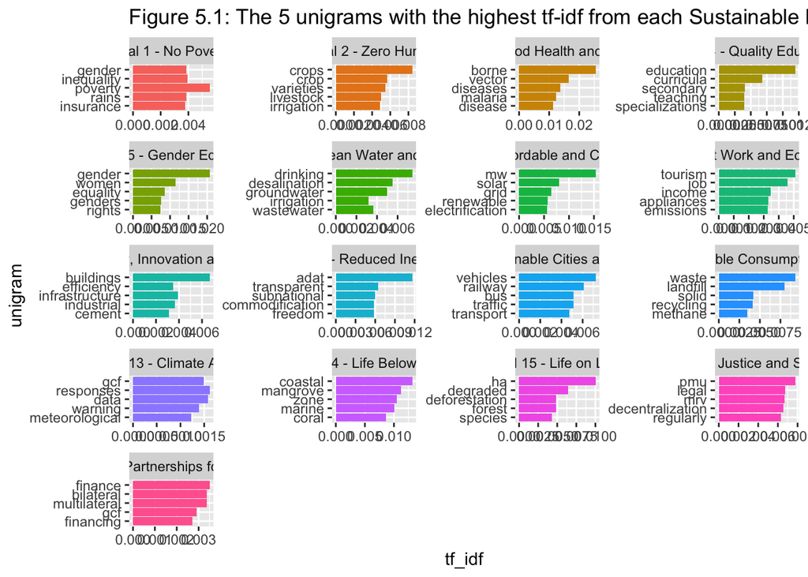

```r
# visualize the result
unigram_tfidf %>%
  arrange(desc(tf_idf)) %>%
  mutate(unigram = factor(unigram, levels = rev(unique(unigram)))) %>%
  group_by(goal) %>%
  slice(1:5) %>%
  ungroup() %>%
  ggplot(aes(unigram, tf_idf, fill = goal)) +
  geom_col(show.legend = FALSE) +
  labs(title = "Figure 5.1: The 5 unigrams with the highest tf-idf from each Sustainable Development Goals") +
  facet_wrap(~goal, ncol = 4, scales = "free") +
  coord_flip()
```

#### 4.2 Bigram

```r
# calculate the number of times that the bigram is used in that goal
bigram_tfidf <- token2_linkages %>%
  count(goal, bigram, sort = TRUE) %>%
  bind_tf_idf(bigram, goal, n) %>%
  arrange(desc(tf_idf))

bigram_tfidf
```

```
## # A tibble: 36,061 x 6
##    goal                               bigram              n      tf   idf tf_idf
##    <fct>                              <chr>           <int>   <dbl> <dbl>  <dbl>
##  1 Goal 3 - Good Health and Well-bei… vector borne       21 0.0107   2.83 0.0304
##  2 Goal 3 - Good Health and Well-bei… borne diseases     27 0.0138   2.14 0.0296
##  3 Goal 14 - Life Below Water         coastal zone       31 0.0205   1.22 0.0251
##  4 Goal 3 - Good Health and Well-bei… health sector      26 0.0133   1.73 0.0231
##  5 Goal 5 - Gender Equality           human rights        7 0.0171   1.04 0.0178
##  6 Goal 10 - Reduced Inequalities     inclusive mech…     3 0.0119   1.45 0.0172
##  7 Goal 14 - Life Below Water         coastal erosion    12 0.00795  2.14 0.0170
##  8 Goal 5 - Gender Equality           gender respons…     4 0.00978  1.73 0.0170
##  9 Goal 16 - Peace, Justice and Stro… sectoral adapt…     4 0.00789  2.14 0.0169
## 10 Goal 10 - Reduced Inequalities     human rights        4 0.0158   1.04 0.0165
## # … with 36,051 more rows
```

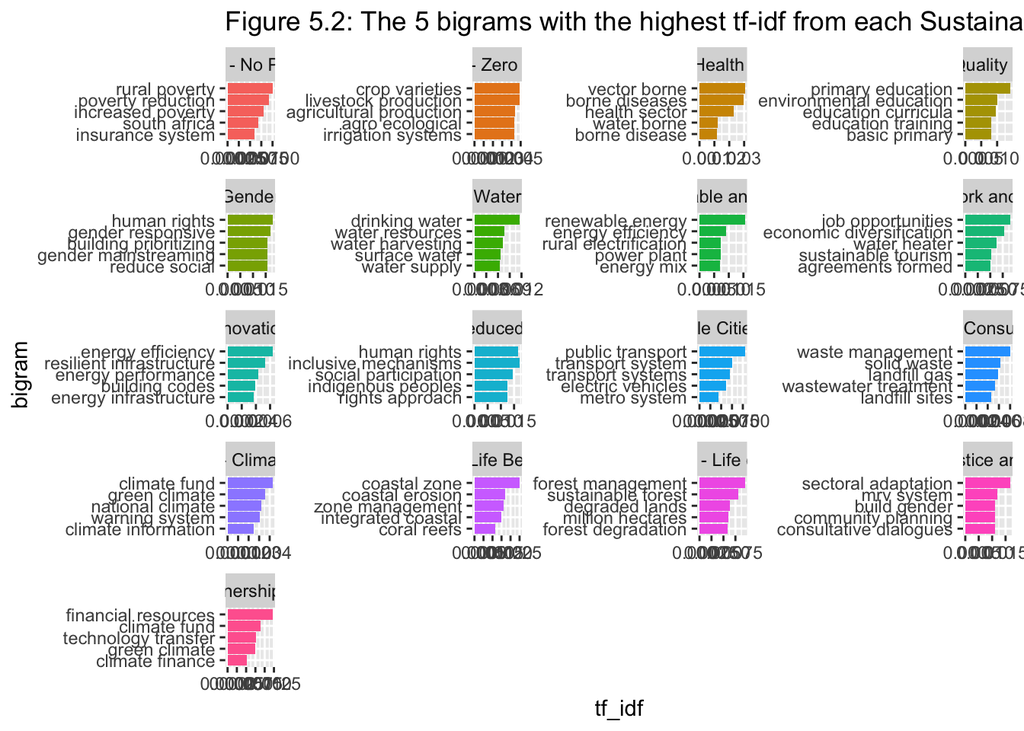

```r
# visualize the result
bigram_tfidf %>%
  arrange(desc(tf_idf)) %>%
  mutate(bigram = factor(bigram, levels = rev(unique(bigram)))) %>%
  group_by(goal) %>%
  slice(1:5) %>%
  ungroup() %>%
  ggplot(aes(bigram, tf_idf, fill = goal)) +
  geom_col(show.legend = FALSE) +
  labs(title = "Figure 5.2: The 5 bigrams with the highest tf-idf from each Sustainable Development Goals") +
  facet_wrap(~goal, ncol = 4, scales = "free") +
  coord_flip()
```

#### 4.3 Remove sparse terms

Now we can continue preparing the data to create the document term matrix with tf-idf weight.

- Document-term matrix for unigrams

```r
dtm_unigram <- token1_linkages %>%
  count(id, unigram) %>%
  cast_dtm(document = id,
           term = unigram,
           value = n,
           weighting = tm::weightTfIdf)
dtm_unigram
```

```
## <<DocumentTermMatrix (documents: 9602, terms: 7130)>>
## Non-/sparse entries: 114117/68348143
## Sparsity           : 100%
## Maximal term length: 20
## Weighting          : term frequency - inverse document frequency (normalized) (tf-idf)
```

Using large, sparse matrices will make our modeling difficult. Of over 68348143 entries, only 114117 of them were non-zero, which might cause computation issues if we do a lot of complex modeling. As we can tell from the sparsity, we may want to remove sparse terms **removeSparseTerms()** can be used here.

Deciding on matrix sparsity depends on how many terms are in the matrix and how fast the computer is. We could try different numbers of maximum sparsity.

```r
# try the value of .9
dtm_unigram_1 <- dtm_unigram %>%
  removeSparseTerms(sparse = .9)

dtm_unigram_1
```

```
## <<DocumentTermMatrix (documents: 9602, terms: 6)>>
## Non-/sparse entries: 8107/49505
## Sparsity           : 86%
## Maximal term length: 11
## Weighting          : term frequency - inverse document frequency (normalized) (tf-idf)
```

```r
# try the value of .99
dtm_unigram_2 <- dtm_unigram %>%
  removeSparseTerms(sparse = .99)

dtm_unigram_2
```

```
## <<DocumentTermMatrix (documents: 9602, terms: 231)>>
## Non-/sparse entries: 58650/2159412
## Sparsity           : 97%
## Maximal term length: 14
## Weighting          : term frequency - inverse document frequency (normalized) (tf-idf)
```

Here I choose the value of 0.99 since it will give us 231 terms for prediction, which can save us a lot of time than previous 7130 terms and give us more preciseness than only 6 terms. Although the sparsity didn’t change that much here, the number of terms is reduced greatly.

```r
dtm_unigram <- dtm_unigram %>%
  removeSparseTerms(sparse = .99)

dtm_unigram
```

```
## <<DocumentTermMatrix (documents: 9602, terms: 231)>>
## Non-/sparse entries: 58650/2159412
## Sparsity           : 97%
## Maximal term length: 14
## Weighting          : term frequency - inverse document frequency (normalized) (tf-idf)
```

- Document-term matrix for bigrams

```r
dtm_bigram <- token2_linkages %>%
  count(id, bigram) %>%
  cast_dtm(document = id,
           term = bigram,
           value = n,
           weighting = tm::weightTfIdf)
dtm_bigram
```

```
## <<DocumentTermMatrix (documents: 9473, terms: 23215)>>
## Non-/sparse entries: 60119/219855576
## Sparsity           : 100%
## Maximal term length: 34
## Weighting          : term frequency - inverse document frequency (normalized) (tf-idf)
```

```r
# try the value of .9
dtm_bigram_1 <- dtm_bigram %>%
  removeSparseTerms(sparse = .99)

dtm_bigram_1
```

```
## <<DocumentTermMatrix (documents: 9473, terms: 14)>>
## Non-/sparse entries: 3578/129044
## Sparsity           : 97%
## Maximal term length: 17
## Weighting          : term frequency - inverse document frequency (normalized) (tf-idf)
```

```r
# try the value of .99
dtm_bigram_2 <- dtm_bigram %>%
  removeSparseTerms(sparse = .999)

dtm_bigram_2
```

```
## <<DocumentTermMatrix (documents: 9473, terms: 653)>>
## Non-/sparse entries: 17131/6168738
## Sparsity           : 100%
## Maximal term length: 28
## Weighting          : term frequency - inverse document frequency (normalized) (tf-idf)
```

Here I choose the value of 0.999 since it will give us 653 terms for prediction, which can save us a lot of time than previous 23215 terms and give us more preciseness than only 14 terms.

```r
dtm_bigram <- dtm_bigram %>%
  removeSparseTerms(sparse = .999)

dtm_bigram
```

```
## <<DocumentTermMatrix (documents: 9473, terms: 653)>>
## Non-/sparse entries: 17131/6168738
## Sparsity           : 100%
## Maximal term length: 28
## Weighting          : term frequency - inverse document frequency (normalized) (tf-idf)
```